# Homework 3 - Markdown Script - 2202157

Owen Preston

2023-03-02

# Setup

### load tidyverse

```r
library(tidyverse)
```

### set options and scipen

```r
options(scipen = 5, digits = 3)
```

### set working directory

```r
setwd("~/GitHub/PS947---Homework-3---2202157")
```

### load lme4

```r
library(lme4)
```

# QUESTION 1

# QUESTION 2 - RECOMMENDATIONS ON CHOICE

### import data and summarise

```r
d <- read.csv("recommendations.csv", row.names = 1)
summary(d)
```

```
##   ResponseID            Mode               Gender          Age
##  Length:1572        Length:1572        Min.   :1.00   Min.   :18.0
##  Class :character   Class :character   1st Qu.:1.00   1st Qu.:24.0
##  Mode  :character   Mode  :character   Median :1.00   Median :30.0
##                                        Mean   :1.49   Mean   :33.7
##                                        3rd Qu.:2.00   3rd Qu.:41.0
##                                        Max.   :3.00   Max.   :75.0
##    Competent     Intelligent     Thoughtful   CompositeIntellect
##  Min.   :1.00   Min.   :1.00   Min.   :1.00   Min.   :1.00
##  1st Qu.:4.00   1st Qu.:5.00   1st Qu.:4.00   1st Qu.:4.33
##  Median :6.00   Median :5.00   Median :5.00   Median :5.33
##  Mean   :5.55   Mean   :5.52   Mean   :5.12   Mean   :5.40
##  3rd Qu.:7.00   3rd Qu.:7.00   3rd Qu.:6.00   3rd Qu.:6.67
##  Max.   :9.00   Max.   :9.00   Max.   :9.00   Max.   :9.00
##    Stimulus         RecommendationFollowed
##  Length:1572        Min.   :0.000
##  Class :character   1st Qu.:0.000
##  Mode  :character   Median :0.000
##                     Mean   :0.454
##                     3rd Qu.:1.000
##                     Max.   :1.000
```

## Part 2.1 - Fit a model and justify

```r
m <- glmer(data = d,
         RecommendationFollowed ~ Mode + (1 | ResponseID),
         family = binomial(link = "logit"));summary(m)
```

```
## Generalized linear mixed model fit by maximum likelihood (Laplace
##   Approximation) [glmerMod]
##  Family: binomial  ( logit )
## Formula: RecommendationFollowed ~ Mode + (1 | ResponseID)
##    Data: d
##
##      AIC      BIC   logLik deviance df.resid
##     2053     2069    -1024     2047     1569
##
## Scaled residuals:
##    Min     1Q Median     3Q    Max
## -1.372 -0.758 -0.464  0.729  1.520
##
## Random effects:
##  Groups     Name        Variance Std.Dev.
##  ResponseID (Intercept) 1.4      1.18
## Number of obs: 1572, groups:  ResponseID, 393
##
## Fixed effects:
##             Estimate Std. Error z value Pr(>|z|)
## (Intercept)   0.0892     0.1178    0.76  0.44903
## ModeVisual   -0.6339     0.1680   -3.77  0.00016 ***
## ---
## Signif. codes:  0 '***' 0.001 '**' 0.01 '*' 0.05 '.' 0.1 ' ' 1
##
## Correlation of Fixed Effects:
##            (Intr)
## ModeVisual -0.705
```

### JUSTIFICATION: General linear mixed effects model was used because looking at the relationship between two variables (e.g. how Mode predicts RecommendationFollowed). Both variables are binomial e.g. Mode is either visual or auditory and RecommendationFollowed as 1 = YES and 0 = NO hence the use of the binomial link function. Mixed effects model used as cannot assume each observation in our data frame is truly independent as repeated measures design was used for the stimulus where each participant did of the four stimuli.

## Part 2.2 - Use model/ plots qualitatively assess evidence for recommendation mode affecting choice

### Make a graph

[figure not shown]

```r
d %>%
  ggplot(aes(x = RecommendationFollowed, y = Stimulus, fill = factor(Mode))) +
  geom_bar(stat="identity", position="dodge")+
  xlab("Recommendation")+ylab("Stimulus")+
  theme(legend.position = "top")+
  labs(fill = "ResponseID")
```

#### attempted a graph, not working, had to give-up

# QUESTION 3 - SOCIAL JUDGEMENTS OF FACES

## Part 3.1 - Replicate PCA from Oosterhof and Todorov (2008)

### read data file and summarise the data

```r
d2 <- read.csv("faces.csv")
summary(d2)
```

```
##  Karolinska.Label   Todorov.Label         gender            attractive
##  Length:66          Length:66          Length:66          Min.   :-1.190
##  Class :character   Class :character   Class :character   1st Qu.:-0.580
##  Mode  :character   Mode  :character   Mode  :character   Median :-0.160
##                                                           Mean   : 0.000
##                                                           3rd Qu.: 0.405
##                                                           Max.   : 1.480
##      caring         aggressive          mean        intelligent
##  Min.   :-1.350   Min.   :-1.160   Min.   :-1.25   Min.   :-1.710
##  1st Qu.:-0.430   1st Qu.:-0.472   1st Qu.:-0.49   1st Qu.:-0.385
##  Median : 0.020   Median :-0.075   Median :-0.03   Median : 0.025
##  Mean   : 0.000   Mean   : 0.000   Mean   : 0.00   Mean   : 0.000
##  3rd Qu.: 0.498   3rd Qu.: 0.320   3rd Qu.: 0.31   3rd Qu.: 0.385
##  Max.   : 1.230   Max.   : 1.480   Max.   : 1.82   Max.   : 0.880
##    confident      emotionally.stable  trustworthy      responsible
##  Min.   :-1.490   Min.   :-1.670     Min.   :-1.560   Min.   :-1.550
##  1st Qu.:-0.270   1st Qu.:-0.368     1st Qu.:-0.302   1st Qu.:-0.378
##  Median : 0.085   Median : 0.085     Median : 0.000   Median : 0.000
##  Mean   : 0.000   Mean   : 0.000     Mean   : 0.000   Mean   : 0.000
##  3rd Qu.: 0.465   3rd Qu.: 0.402     3rd Qu.: 0.455   3rd Qu.: 0.537
##  Max.   : 1.070   Max.   : 1.230     Max.   : 1.350   Max.   : 1.200
##     sociable          weird           unhappy          dominant
##  Min.   :-1.430   Min.   :-1.220   Min.   :-1.020   Min.   :-1.330
##  1st Qu.:-0.450   1st Qu.:-0.552   1st Qu.:-0.455   1st Qu.:-0.280
##  Median :-0.030   Median :-0.045   Median :-0.110   Median : 0.010
##  Mean   :-0.001   Mean   : 0.000   Mean   : 0.000   Mean   : 0.000
##  3rd Qu.: 0.532   3rd Qu.: 0.440   3rd Qu.: 0.547   3rd Qu.: 0.405
##  Max.   : 1.090   Max.   : 1.860   Max.   : 1.510   Max.   : 1.180
##   threatening
##  Min.   :-1.270
##  1st Qu.:-0.380
##  Median :-0.135
##  Mean   : 0.000
##  3rd Qu.: 0.390
##  Max.   : 1.760
```

### conduct PCA

```r
q2pca <- prcomp(~ attractive + caring + aggressive + mean + intelligent + confident + emotionally.stable + trustworthy + responsible + sociable + weird + unhappy + dominant + threatening , d2, scale = TRUE)
summary(q2pca)
```

```
## Importance of components:
##                          PC1   PC2    PC3    PC4    PC5    PC6   PC7     PC8
## Standard deviation     2.966 1.628 0.8957 0.8176 0.5314 0.4524 0.392 0.31573
## Proportion of Variance 0.628 0.189 0.0573 0.0478 0.0202 0.0146 0.011 0.00712
## Cumulative Proportion  0.628 0.818 0.8751 0.9228 0.9430 0.9576 0.969 0.97572
##                            PC9    PC10    PC11    PC12    PC13   PC14
## Standard deviation     0.29184 0.26940 0.25411 0.22067 0.19906 0.1713
## Proportion of Variance 0.00608 0.00518 0.00461 0.00348 0.00283 0.0021
## Cumulative Proportion  0.98180 0.98698 0.99160 0.99507 0.99790 1.0000
```

### load factoextra

```r
library(factoextra)
```

### create scree plot

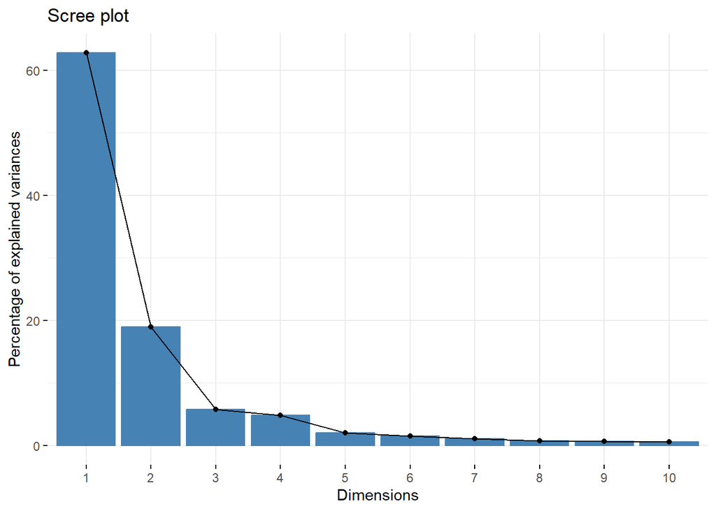

```r
factoextra::fviz_eig(q2pca)
```

### CONCLUSION Oosterhof and Todorov (2008) found that their first two principal components accounted for more than 80% of the variance with their first principal component accounting for more than 60% of the variance. My PCA revealed that that the cumulative proportion of variance explained by the the first two principal components was 81.8% with the first principle component accounting for 62.8% of the variance. Thus my PCA replicated the PCA results found by Oosterhof and Todoro (2008).

## Part 3.2 - Testing two factor model on ′faces_big.csv′

```r
d3 <- read.csv("faces_big.csv")
summary(d3)
```

```
##    aggressive      attractive         caring         confident
##  Min.   :-1.74   Min.   :-1.545   Min.   :-2.437   Min.   :-2.030
##  1st Qu.:-0.76   1st Qu.:-0.813   1st Qu.:-0.739   1st Qu.:-0.786
##  Median :-0.10   Median :-0.241   Median :-0.011   Median :-0.079
##  Mean   : 0.00   Mean   : 0.000   Mean   : 0.000   Mean   : 0.000
##  3rd Qu.: 0.64   3rd Qu.: 0.642   3rd Qu.: 0.651   3rd Qu.: 0.792
##  Max.   : 3.80   Max.   : 2.999   Max.   : 2.292   Max.   : 2.139
##     dominant        emostable       intelligent          mean
##  Min.   :-2.196   Min.   :-2.791   Min.   :-2.969   Min.   :-1.90
##  1st Qu.:-0.733   1st Qu.:-0.673   1st Qu.:-0.755   1st Qu.:-0.70
##  Median :-0.158   Median :-0.010   Median : 0.115   Median :-0.07
##  Mean   : 0.000   Mean   : 0.000   Mean   : 0.000   Mean   : 0.00
##  3rd Qu.: 0.633   3rd Qu.: 0.693   3rd Qu.: 0.796   3rd Qu.: 0.59
##  Max.   : 2.390   Max.   : 2.243   Max.   : 1.691   Max.   : 3.64
##       old         responsible        sociable       trustworthy
##  Min.   :-2.23   Min.   :-2.998   Min.   :-2.244   Min.   :-2.850
##  1st Qu.:-0.70   1st Qu.:-0.638   1st Qu.:-0.805   1st Qu.:-0.752
##  Median :-0.12   Median :-0.066   Median :-0.044   Median : 0.098
##  Mean   : 0.00   Mean   : 0.000   Mean   : 0.000   Mean   : 0.000
##  3rd Qu.: 0.68   3rd Qu.: 0.723   3rd Qu.: 0.648   3rd Qu.: 0.706
##  Max.   : 3.18   Max.   : 2.162   Max.   : 2.552   Max.   : 2.035
##     unhappy           weird
##  Min.   :-2.524   Min.   :-2.024
##  1st Qu.:-0.608   1st Qu.:-0.768
##  Median : 0.026   Median :-0.110
##  Mean   : 0.000   Mean   : 0.000
##  3rd Qu.: 0.606   3rd Qu.: 0.707
##  Max.   : 2.400   Max.   : 2.684
```

### load lavaan

```r
library(lavaan)
```

### Define the latent factors for valence and dominance

```r
sjofcomponents <- 'valence =~ trustworthy + caring + responsible + sociable
dominance =~ dominant + confident + aggressive + mean'
```

## Part 3.3 - Run model, Conclusions about hypothesis

```r
model_field <- cfa(sjofcomponents, d3)
summary(model_field)
```

```
## lavaan 0.6.14 ended normally after 70 iterations
##
##   Estimator                                         ML
##   Optimization method                           NLMINB
##   Number of model parameters                        17
##
##   Number of observations                           120
##
## Model Test User Model:
##
##   Test statistic                               820.636
##   Degrees of freedom                                19
##   P-value (Chi-square)                           0.000
##
## Parameter Estimates:
##
##   Standard errors                             Standard
##   Information                                 Expected
##   Information saturated (h1) model          Structured
##
## Latent Variables:
##                    Estimate  Std.Err  z-value  P(>|z|)
##   valence =~
##     trustworthy       1.000
##     caring            1.004    0.041   24.589    0.000
##     responsible       0.869    0.060   14.481    0.000
##     sociable          1.008    0.040   25.057    0.000
##   dominance =~
##     dominant          1.000
##     confident        -0.756    0.332   -2.276    0.023
##     aggressive        2.973    0.778    3.823    0.000
##     mean              2.882    0.755    3.816    0.000
##
## Covariances:
##                    Estimate  Std.Err  z-value  P(>|z|)
##   valence ~~
##     dominance        -0.251    0.075   -3.321    0.001
##
## Variances:
##                    Estimate  Std.Err  z-value  P(>|z|)
##    .trustworthy       0.088    0.016    5.503    0.000
##    .caring            0.081    0.015    5.268    0.000
##    .responsible       0.310    0.043    7.288    0.000
##    .sociable          0.075    0.015    5.037    0.000
##    .dominant          0.882    0.114    7.730    0.000
##    .confident         0.929    0.120    7.737    0.000
##    .aggressive        0.020    0.022    0.905    0.366
##    .mean              0.079    0.023    3.437    0.001
##     valence           0.903    0.128    7.056    0.000
##     dominance         0.110    0.059    1.862    0.063
```

### install and load tidySEM

```r
library(tidySEM)
```

### visualise the model

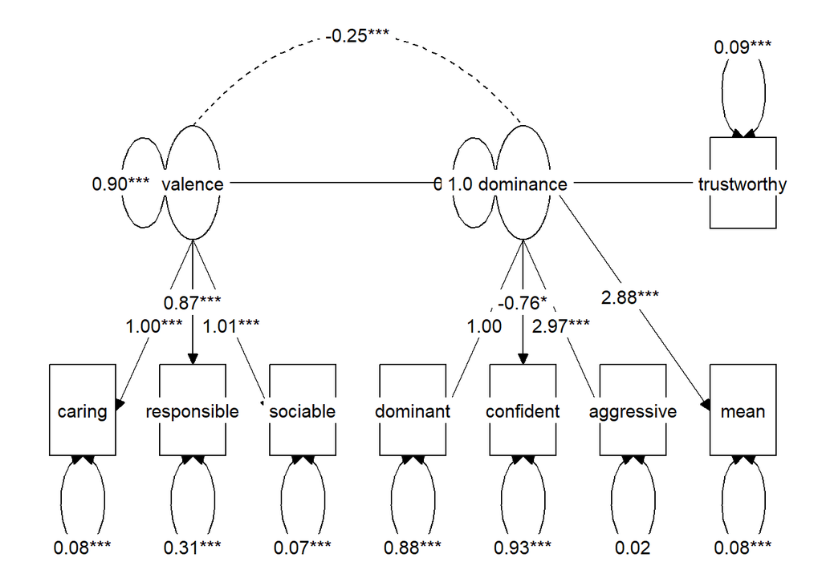

```r
graph_sem(model_field,
          layout = get_layout("", "valence", "", "", "dominance", "",
                              "trustworthy" , "caring" , "responsible" , "sociable", "dominant" , "confident", "aggressive" , "mean",
                              rows = 2))
```

### model fit

```r
summary(model_field, fit.measures = TRUE)
```

```
## lavaan 0.6.14 ended normally after 70 iterations
##
##   Estimator                                         ML
##   Optimization method                           NLMINB
##   Number of model parameters                        17
##
##   Number of observations                           120
##
## Model Test User Model:
##
##   Test statistic                               820.636
##   Degrees of freedom                                19
##   P-value (Chi-square)                           0.000
##
## Model Test Baseline Model:
##
##   Test statistic                              1839.983
##   Degrees of freedom                                28
##   P-value                                        0.000
##
## User Model versus Baseline Model:
##
##   Comparative Fit Index (CFI)                    0.558
##   Tucker-Lewis Index (TLI)                       0.348
##
## Loglikelihood and Information Criteria:
##
##   Loglikelihood user model (H0)               -848.491
##   Loglikelihood unrestricted model (H1)       -438.173
##
##   Akaike (AIC)                                1730.982
##   Bayesian (BIC)                              1778.369
##   Sample-size adjusted Bayesian (SABIC)       1724.623
##
## Root Mean Square Error of Approximation:
##
##   RMSEA                                          0.593
##   90 Percent confidence interval - lower         0.559
##   90 Percent confidence interval - upper         0.628
##   P-value H_0: RMSEA <= 0.050                    0.000
```

[output cut: 27 more lines]

```
##   valence ~~
##     dominance        -0.251    0.075   -3.321    0.001
##
## Variances:
##                    Estimate  Std.Err  z-value  P(>|z|)
##    .trustworthy       0.088    0.016    5.503    0.000
##    .caring            0.081    0.015    5.268    0.000
##    .responsible       0.310    0.043    7.288    0.000
##    .sociable          0.075    0.015    5.037    0.000
##    .dominant          0.882    0.114    7.730    0.000
##    .confident         0.929    0.120    7.737    0.000
##    .aggressive        0.020    0.022    0.905    0.366
##    .mean              0.079    0.023    3.437    0.001
##     valence           0.903    0.128    7.056    0.000
##     dominance         0.110    0.059    1.862    0.063
```

### To pass RMSEA < 0.07

```r
fitMeasures(model_field) ["rmsea"]
```

```
## rmsea
## 0.593
```

### CONCLUSION: RMSEA = 0.593 thus RMSEA not < 0.07 thus model does not account well for the data

### To pass CFI >= 0.9

```r
fitMeasures(model_field) ["cfi"]
```

```
##   cfi
## 0.558
```

### CONCLUSION: CFI = 0.558 thus CFI not >= 0.9 thus model does not account well for the data

### CONLUSION: Based on these measures, it seems like Dr Hughes’ hypothesis (that ‘trustworthy’, ‘caring’, ‘responsible’ and ‘sociable’ should load onto the ‘valence’ factor, and ‘dominant’, ‘confident’, ‘aggressive’ and ‘mean’ should load onto the ‘dominance’ factor) is not supported by the data.